# Intro_exos_1et2CSV

# corrélation

1. Prenez un subset des pays puis calculez la corrélation des revenus entre chaque pays.
2. Afficher le résultat sur une heatmap.
3. Prenez cette fois l'ensemble des pays et calculez la corrélation entre chaque pays.
4. Tracez un historamme de corrélations. Que pouvez-vous conclure de cette histogramme ? A votre avis, quel est le signe de la skewness ?
5. Trouvez les pays dont les revenus sont en moyenne les moins corrélés aux autres.
6. Trouvez les paires de pays dont les revenus sont les moins corrélés.
7. Tracez l'évolution de la corrélation entre revenus et espérance de vie au cours du temps.

**Pré-traitement des données** Avant d'effectuer les calculs de corrélation, il est essentiel de nettoyer et de préparer le fichier income.csv. Cela implique de gérer les valeurs manquantes (...) et de s'assurer que toutes les données sont au format numérique.

Action : Je vais charger le fichier, définir country comme index, puis convertir toutes les colonnes d'années en un type numérique.

```python
import pandas as pd
import numpy as np
import matplotlib.pyplot as plt
import seaborn as sns

# Charger les données de revenus
df_income = pd.read_csv('income.csv', index_col='country')

# Convertir les colonnes d'années en type numérique, en gérant les valeurs non-numériques
for col in df_income.columns:
    df_income[col] = pd.to_numeric(df_income[col], errors='coerce')

print("Fichier de revenus chargé et nettoyé.")
```

```
Fichier de revenus chargé et nettoyé.
```

1. Calculer la corrélation sur un sous-ensemble de pays Pour la première étape, nous allons sélectionner un petit groupe de pays pour rendre la visualisation plus lisible et plus facile à interpréter.

Action : Créer une liste de pays, puis calculer leur matrice de corrélation

```python
# Sélectionner un sous-ensemble de pays
subset_countries = ['France', 'Germany', 'Japan', 'United States', 'China', 'Brazil']

# Filtrer le DataFrame pour ne garder que ces pays
df_subset = df_income.loc[subset_countries].T # Transposer pour que les pays soient des colonnes

# Calculer la matrice de corrélation
correlation_subset = df_subset.corr()

print("Matrice de corrélation pour le sous-ensemble de pays :")
print(correlation_subset)
```

```
Matrice de corrélation pour le sous-ensemble de pays :
country          France   Germany     Japan  United States     China    Brazil
country
France         1.000000  0.932644  0.834053       0.950839  0.594161  0.775297
Germany        0.932644  1.000000  0.928501       0.979164  0.720540  0.718300
Japan          0.834053  0.928501  1.000000       0.794767  0.558362  0.887784
United States  0.950839  0.979164  0.794767       1.000000  0.736037  0.646534
China          0.594161  0.720540  0.558362       0.736037  1.000000  0.725208
Brazil         0.775297  0.718300  0.887784       0.646534  0.725208  1.000000
```

2. Afficher le résultat sur une heatmap Une heatmap est la meilleure façon de visualiser une matrice de corrélation. La couleur de chaque cellule indique le niveau et le sens de la corrélation, ce qui permet de repérer rapidement les relations fortes ou faibles.

Action : Utiliser seaborn.heatmap pour tracer la matrice de corrélation.

```
<function matplotlib.pyplot.show(close=None, block=None)>
```

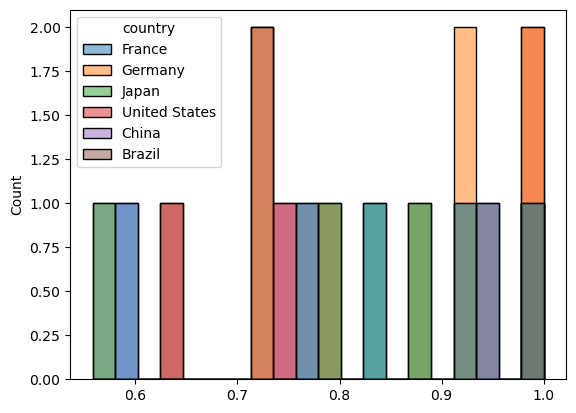

```python
#skewness/kurtosis il est en False met en True pour le faire apparaitre
sns.histplot(correlation_subset, kde=False, bins=20, color='lightgreen')
plt.figure(figsize=(10, 8))
plt.show
```

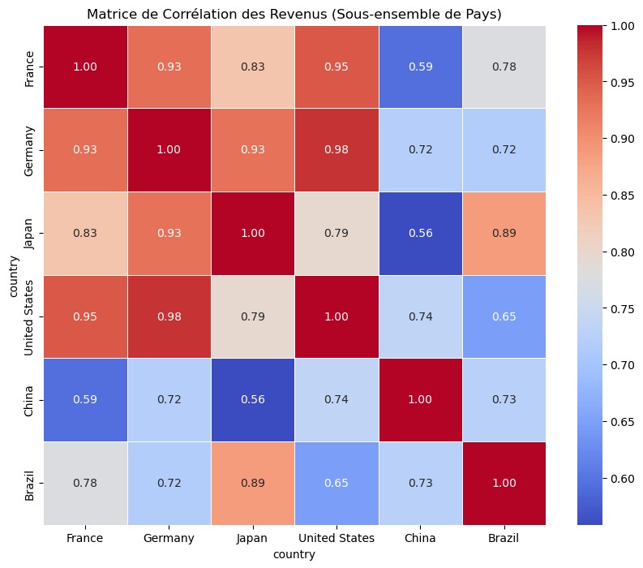

```python
plt.figure(figsize=(10, 8))
sns.heatmap(correlation_subset, annot=True, cmap='coolwarm', fmt=".2f", linewidths=.5)
plt.title("Matrice de Corrélation des Revenus (Sous-ensemble de Pays)")
plt.show()
```

3. Calculer la corrélation sur l'ensemble des pays Nous allons maintenant étendre l'analyse à tous les pays pour obtenir une vue d'ensemble de la similarité des trajectoires de revenus à l'échelle mondiale.

Action : Calculer la matrice de corrélation pour l'ensemble du DataFrame.

```python
# Transposer l'ensemble du DataFrame pour que les pays soient des colonnes
df_all_countries = df_income.T

# Calculer la matrice de corrélation
correlation_all = df_all_countries.corr()

print("Matrice de corrélation calculée pour tous les pays.")
print(f"La matrice a une taille de : {correlation_all.shape[0]}x{correlation_all.shape[1]}")
```

```
Matrice de corrélation calculée pour tous les pays.
La matrice a une taille de : 195x195
```

4. Tracer l'histogramme des corrélations Pour résumer la distribution de toutes les corrélations, nous allons tracer un histogramme.

Action : Convertir la matrice de corrélation en une série, puis tracer un histogramme de ces valeurs.

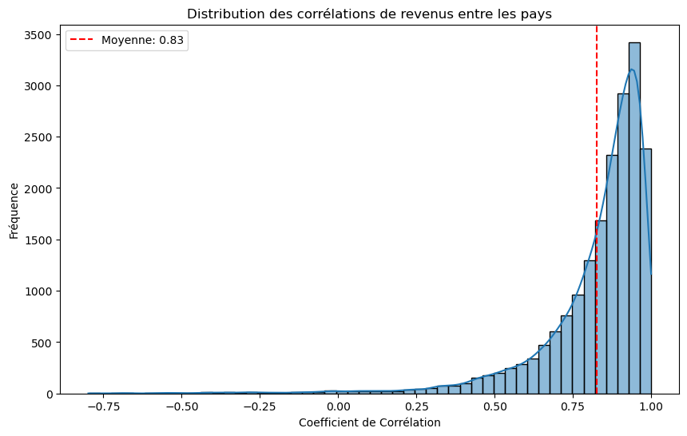

```
Skewness de l'histogramme des corrélations : -2.95
```

```python
# Extraire les valeurs de corrélation de la matrice, en retirant la diagonale (corrélation d'un pays avec lui-même)
correlation_values = correlation_all.values[np.triu_indices_from(correlation_all.values, k=1)]

# Tracer l'histogramme des corrélations
plt.figure(figsize=(10, 6))
sns.histplot(correlation_values, bins=50, kde=True)
plt.title("Distribution des corrélations de revenus entre les pays")
plt.xlabel("Coefficient de Corrélation")
plt.ylabel("Fréquence")
plt.axvline(correlation_values.mean(), color='red', linestyle='--', label=f'Moyenne: {correlation_values.mean():.2f}')
plt.legend()
plt.show()

# Calculer la skewness
skewness_corr = pd.Series(correlation_values).skew()
print(f"Skewness de l'histogramme des corrélations : {skewness_corr:.2f}")
```

**Analyse** : L'histogramme montre une forte concentration de corrélations positives et élevées, avec un pic à droite. Cela signifie que la majorité des paires de pays ont des revenus qui évoluent de manière similaire. La distribution est asymétrique négativement (skewness négative), car il y a une longue queue sur la gauche, représentant les rares paires de pays dont les revenus sont faiblement, voire négativement, corrélés.

5. Trouver les pays les moins corrélés aux autres Pour trouver les pays les moins corrélés en moyenne, nous allons calculer la moyenne des coefficients de corrélation pour chaque pays.

Action : Calculer la moyenne de chaque colonne de la matrice de corrélation, puis trier pour trouver les valeurs les plus faibles.

```python
# Calculer la moyenne des corrélations pour chaque pays
mean_correlations = correlation_all.mean().sort_values()

print("Top 10 des pays dont les revenus sont en moyenne les moins corrélés aux autres :")
print(mean_correlations.head(10))
```

```
Top 10 des pays dont les revenus sont en moyenne les moins corrélés aux autres :
country
Mozambique          0.407719
Myanmar             0.427710
Venezuela           0.466702
Lao                 0.482544
Qatar               0.508877
Oman                0.551860
Congo, Dem. Rep.    0.628521
China               0.640092
Bangladesh          0.641529
Brunei              0.664306
dtype: float64
```

6. Trouver les paires de pays les moins corrélées Pour trouver les paires les moins corrélées, nous allons extraire les valeurs minimales de la matrice de corrélation.

**Pré-traitement des données** Avant d'effectuer les calculs de corrélation, il est essentiel de nettoyer et de préparer le fichier income.csv. Cela implique de gérer les valeurs manquantes (...) et de s'assurer que toutes les données sont au format numérique.

```python
# Charger les données de revenus
df_income = pd.read_csv('income.csv', index_col='country')

# Convertir les colonnes d'années en type numérique, en gérant les valeurs non-numériques
for col in df_income.columns:
    df_income[col] = pd.to_numeric(df_income[col], errors='coerce')

# Transposer le DataFrame pour que les pays soient des colonnes
df_all_countries = df_income.T

# --- Début de la correction ---
# La ligne suivante supprime le nom de l'index pour éviter le conflit de nom
df_all_countries.columns.name = None
# --- Fin de la correction ---

# Calculer la matrice de corrélation
correlation_all = df_all_countries.corr()

# Empiler la matrice de corrélation pour avoir un format 'long'
corr_stacked = correlation_all.stack().reset_index()

# Renommer les colonnes
corr_stacked.columns = ['country1', 'country2', 'correlation']

# Filtrer pour ne garder que les paires uniques (éviter les doublons et la corrélation avec soi-même)
corr_stacked = corr_stacked[corr_stacked['country1'] < corr_stacked['country2']]

# Trier par corrélation pour trouver les moins corrélées
least_correlated_pairs = corr_stacked.sort_values(by='correlation')

print("Top 10 des paires de pays dont les revenus sont les moins corrélés :")
print(least_correlated_pairs.head(10))
```

```
Top 10 des paires de pays dont les revenus sont les moins corrélés :
         country1              country2  correlation
23343  Mozambique                 Palau    -0.798215
23380  Mozambique   Trinidad and Tobago    -0.784300
35104    Tanzania  United Arab Emirates    -0.708792
11039     Finland            Mozambique    -0.691865
23397  Mozambique          South Africa    -0.685312
23354  Mozambique          Saudi Arabia    -0.683780
23361  Mozambique            San Marino    -0.678280
16304      Israel            Mozambique    -0.676378
20204   Lithuania            Mozambique    -0.671584
23367  Mozambique       Slovak Republic    -0.606510
```

```python
def to_real_number(value_str):
    if isinstance(value_str, (int, float)):
        return int(value_str)

    value_str = str(value_str).lower().strip()

    if 'k' in value_str:
        # Supprimer le 'k' et remplacer la virgule par un point si nécessaire
        value_str = value_str.replace('k', '').replace(',', '.')
        # Convertir en float et multiplier par 1000
        return int(float(value_str) * 1000)
    else:
        # Convertir la chaîne en entier directement
        return int(value_str)
# Charger les données de revenus
df_income = pd.read_csv('income.csv', index_col='country')

# Convertir les colonnes d'années en type numérique, en gérant les valeurs non-numériques
for col in df_income.columns:
    df_income[col] = df_income[col].apply(to_real_number)

# Transposer le DataFrame pour que les pays soient des colonnes
df_all_countries = df_income.T

# --- Début de la correction ---
# La ligne suivante supprime le nom de l'index pour éviter le conflit de nom
df_all_countries.columns.name = None
# --- Fin de la correction ---

# Calculer la matrice de corrélation
correlation_all = df_all_countries.corr()

# Empiler la matrice de corrélation pour avoir un format 'long'
corr_stacked = correlation_all.stack().reset_index()

# Renommer les colonnes
corr_stacked.columns = ['country1', 'country2', 'correlation']

corr_stacked['correlation'] = corr_stacked['correlation'].abs() # introduire la valeur absolue avec la fonction abs()
# la fonction abs() dans une corrélation permet de se concentrer sur le zéros donc mettre les valeurs moins corréler
# on enléve tout ce qui est négatif ()

# Filtrer pour ne garder que les paires uniques (éviter les doublons et la corrélation avec soi-même)
corr_stacked = corr_stacked[corr_stacked['country1'] < corr_stacked['country2']]

# Trier par corrélation pour trouver les moins corrélées
least_correlated_pairs = corr_stacked.sort_values(by='correlation')

print("Top 10 des paires de pays dont les revenus sont les moins corrélés :")
print(least_correlated_pairs.head(10))
```

```
Top 10 des paires de pays dont les revenus sont les moins corrélés :
                 country1           country2  correlation
23197            Mongolia          Venezuela     0.001303
15592             Ireland          Venezuela     0.014831
25537               Nepal          Venezuela     0.018519
5257               Bhutan          Venezuela     0.021187
15202           Indonesia          Venezuela     0.021861
17932            Cambodia          Venezuela     0.022706
9547   Dominican Republic          Venezuela     0.036894
29047              Rwanda          Venezuela     0.037663
6892     Congo, Dem. Rep.  Equatorial Guinea     0.038548
18907                 Lao          Venezuela     0.044482
```

```python
df_income
```

|  | 1800 | 1801 | 1802 | 1803 | 1804 | 1805 | 1806 | 1807 | 1808 | 1809 | ... | 2041 | 2042 | 2043 | 2044 | 2045 | 2046 | 2047 | 2048 | 2049 | 2050 |
| --- | --- | --- | --- | --- | --- | --- | --- | --- | --- | --- | --- | --- | --- | --- | --- | --- | --- | --- | --- | --- | --- |
| Afghanistan | 683 | 683 | 683 | 683 | 683 | 683 | 683 | 683 | 683 | 683 | ... | 2690 | 2750 | 2810 | 2870 | 2930 | 2990 | 3060 | 3120 | 3190 | 3260 |
| Angola | 700 | 702 | 705 | 709 | 711 | 714 | 718 | 721 | 725 | 727 | ... | 8000 | 8170 | 8350 | 8530 | 8710 | 8900 | 9090 | 9280 | 9480 | 9690 |
| Albania | 755 | 755 | 755 | 755 | 755 | 756 | 756 | 756 | 756 | 756 | ... | 25100 | 25600 | 26200 | 26700 | 27300 | 27900 | 28500 | 29100 | 29700 | 30400 |
| Andorra | 1360 | 1360 | 1360 | 1360 | 1370 | 1370 | 1370 | 1370 | 1380 | 1380 | ... | 68900 | 70400 | 71900 | 73400 | 75000 | 76600 | 78300 | 80000 | 81700 | 83400 |
| United Arab Emirates | 1130 | 1130 | 1140 | 1140 | 1150 | 1150 | 1160 | 1160 | 1160 | 1170 | ... | 101000 | 103000 | 105000 | 107000 | 110000 | 112000 | 114000 | 117000 | 119000 | 122000 |
| ... | ... | ... | ... | ... | ... | ... | ... | ... | ... | ... | ... | ... | ... | ... | ... | ... | ... | ... | ... | ... | ... |
| Samoa | 1590 | 1590 | 1590 | 1590 | 1590 | 1590 | 1590 | 1590 | 1590 | 1590 | ... | 8860 | 9050 | 9250 | 9440 | 9650 | 9860 | 10100 | 10300 | 10500 | 10700 |
| Yemen | 993 | 995 | 998 | 1000 | 1000 | 1010 | 1010 | 1010 | 1020 | 1020 | ... | 3750 | 3830 | 3910 | 3990 | 4080 | 4170 | 4260 | 4350 | 4440 | 4540 |
| South Africa | 1780 | 1760 | 1740 | 1720 | 1700 | 1610 | 1610 | 1750 | 1530 | 1490 | ... | 16200 | 16600 | 16900 | 17300 | 17700 | 18100 | 18500 | 18800 | 19300 | 19700 |
| Zambia | 751 | 753 | 755 | 756 | 758 | 760 | 762 | 764 | 765 | 768 | ... | 4690 | 4790 | 4890 | 5000 | 5110 | 5220 | 5330 | 5440 | 5560 | 5680 |
| Zimbabwe | 984 | 985 | 986 | 987 | 988 | 989 | 991 | 992 | 993 | 994 | ... | 4890 | 4990 | 5100 | 5210 | 5320 | 5440 | 5560 | 5670 | 5800 | 5920 |

195 rows × 251 columns

```python
import pandas as pd
import numpy as np

# --- Début de la fonction intégrée ---
def to_real_number(value_str):
    """
    Convertit une chaîne de caractères (ex: '33k') en un nombre entier.
    Gère les nombres déjà au bon format et les erreurs de conversion.
    """
    # Si la valeur est déjà un nombre, on la retourne directement
    if isinstance(value_str, (int, float)):
        return int(value_str)

    try:
        # On convertit en chaîne, on met en minuscule et on retire les espaces
        value_str = str(value_str).lower().strip()

        # Si la chaîne contient 'k' pour "kilo" (millier)
        if 'k' in value_str:
            # On retire le 'k' et on gère la virgule décimale
            value_str = value_str.replace('k', '').replace(',', '.')
            # On convertit en nombre à virgule, on multiplie par 1000, puis en entier
            return int(float(value_str) * 1000)
        else:
            # Sinon, on convertit simplement la chaîne en entier
            return int(value_str)
    except (ValueError, TypeError):
        # Si une conversion échoue, on retourne NaN (Not a Number) pour ignorer la valeur
        return np.nan
# --- Fin de la fonction intégrée ---


# 1. Charger les données de revenus
df_income = pd.read_csv('income.csv', index_col='country')

# 2. Nettoyer les données en appliquant la fonction personnalisée
# On parcourt chaque colonne (chaque année) pour la convertir
for col in df_income.columns:
    # On applique notre fonction 'to_real_number' à chaque cellule de la colonne
    df_income[col] = df_income[col].apply(to_real_number)

# 3. Transposer le DataFrame pour que les pays soient des colonnes
df_all_countries = df_income.T

# La ligne suivante supprime le nom de l'index pour éviter le conflit de nom
df_all_countries.columns.name = None

# 4. Calculer la matrice de corrélation
correlation_all = df_all_countries.corr()

correlation_all
```

|  | Afghanistan | Angola | Albania | Andorra | United Arab Emirates | Argentina | Armenia | Antigua and Barbuda | Australia | Austria | ... | Uzbekistan | St. Vincent and the Grenadines | Venezuela | Vietnam | Vanuatu | Samoa | Yemen | South Africa | Zambia | Zimbabwe |
| --- | --- | --- | --- | --- | --- | --- | --- | --- | --- | --- | --- | --- | --- | --- | --- | --- | --- | --- | --- | --- | --- |
| Afghanistan | 1.000000 | 0.903270 | 0.908299 | 0.858201 | 0.782313 | 0.881572 | 0.935971 | 0.799597 | 0.887864 | 0.838696 | ... | 0.923865 | 0.879761 | 0.162125 | 0.879104 | 0.775119 | 0.917734 | 0.535016 | 0.832755 | 0.920880 | 0.731138 |
| Angola | 0.903270 | 1.000000 | 0.932366 | 0.928294 | 0.810171 | 0.920964 | 0.929167 | 0.909201 | 0.936683 | 0.924534 | ... | 0.916223 | 0.944909 | 0.273509 | 0.881190 | 0.841877 | 0.947424 | 0.656831 | 0.875389 | 0.952270 | 0.793875 |
| Albania | 0.908299 | 0.932366 | 1.000000 | 0.921626 | 0.791047 | 0.913581 | 0.979442 | 0.922876 | 0.959552 | 0.947041 | ... | 0.973290 | 0.983385 | 0.059911 | 0.985750 | 0.816768 | 0.954574 | 0.610384 | 0.838220 | 0.964933 | 0.837616 |
| Andorra | 0.858201 | 0.928294 | 0.921626 | 1.000000 | 0.940043 | 0.981234 | 0.938630 | 0.958276 | 0.978623 | 0.977756 | ... | 0.951826 | 0.948396 | 0.413831 | 0.847969 | 0.953588 | 0.973233 | 0.806432 | 0.970521 | 0.981960 | 0.946504 |
| United Arab Emirates | 0.782313 | 0.810171 | 0.791047 | 0.940043 | 1.000000 | 0.928280 | 0.860834 | 0.845646 | 0.886895 | 0.875022 | ... | 0.880287 | 0.821859 | 0.573404 | 0.703469 | 0.925134 | 0.908249 | 0.818280 | 0.965880 | 0.904784 | 0.911532 |
| ... | ... | ... | ... | ... | ... | ... | ... | ... | ... | ... | ... | ... | ... | ... | ... | ... | ... | ... | ... | ... | ... |
| Samoa | 0.917734 | 0.947424 | 0.954574 | 0.973233 | 0.908249 | 0.981230 | 0.966072 | 0.955500 | 0.988845 | 0.972295 | ... | 0.965480 | 0.974405 | 0.322428 | 0.902555 | 0.928782 | 1.000000 | 0.759776 | 0.949195 | 0.986246 | 0.903943 |
| Yemen | 0.535016 | 0.656831 | 0.610384 | 0.806432 | 0.818280 | 0.827798 | 0.619777 | 0.825377 | 0.780543 | 0.812381 | ... | 0.645724 | 0.714086 | 0.702910 | 0.497105 | 0.914455 | 0.759776 | 1.000000 | 0.863719 | 0.729792 | 0.872337 |
| South Africa | 0.832755 | 0.875389 | 0.838220 | 0.970521 | 0.965880 | 0.974024 | 0.882744 | 0.917273 | 0.941073 | 0.933476 | ... | 0.899779 | 0.883613 | 0.572138 | 0.745204 | 0.980030 | 0.949195 | 0.863719 | 1.000000 | 0.940750 | 0.942252 |
| Zambia | 0.920880 | 0.952270 | 0.964933 | 0.981960 | 0.904784 | 0.974704 | 0.978156 | 0.942845 | 0.983293 | 0.970017 | ... | 0.983472 | 0.969587 | 0.299933 | 0.914241 | 0.913275 | 0.986246 | 0.729792 | 0.940750 | 1.000000 | 0.911423 |
| Zimbabwe | 0.731138 | 0.793875 | 0.837616 | 0.946504 | 0.911532 | 0.939170 | 0.848569 | 0.931236 | 0.929198 | 0.943847 | ... | 0.880221 | 0.883924 | 0.469900 | 0.761923 | 0.961554 | 0.903943 | 0.872337 | 0.942252 | 0.911423 | 1.000000 |

195 rows × 195 columns

```python
# 5. Empiler la matrice pour avoir un format 'long'
corr_stacked = correlation_all.stack().reset_index()
corr_stacked.columns = ['country1', 'country2', 'correlation']

# 6. Filtrer pour ne garder que les paires uniques
corr_stacked = corr_stacked[corr_stacked['country1'] < corr_stacked['country2']]

# 7. Trier par corrélation pour trouver les moins corrélées
least_correlated_pairs = corr_stacked.sort_values(by='correlation')

least_correlated_pairs

# print("Top 10 des paires de pays dont les revenus sont les moins corrélés :")
# print(least_correlated_pairs.head(10))
```

|  | country1 | country2 | correlation |
| --- | --- | --- | --- |
| 22807 | Myanmar | Venezuela | -0.123932 |
| 3112 | Bangladesh | Venezuela | -0.120861 |
| 6427 | China | Venezuela | -0.112413 |
| 23392 | Mozambique | Venezuela | -0.107484 |
| 10912 | Ethiopia | Venezuela | -0.091455 |
| ... | ... | ... | ... |
| 29810 | Singapore | Thailand | 0.999177 |
| 14593 | Croatia | Slovenia | 0.999235 |
| 18509 | South Korea | Taiwan | 0.999534 |
| 15398 | India | Vietnam | 0.999678 |
| 29819 | Singapore | Taiwan | 0.999724 |

18915 rows × 3 columns

7. Tracer l'évolution de la corrélation entre revenus et espérance de vie Nous allons maintenant analyser la corrélation entre les deux variables, income et life_expectancy, au fil du temps pour voir comment la relation a évolué.

Action : Charger le fichier de l'espérance de vie, le nettoyer, puis calculer la corrélation de Spearman pour chaque année, car la relation est non linéaire.

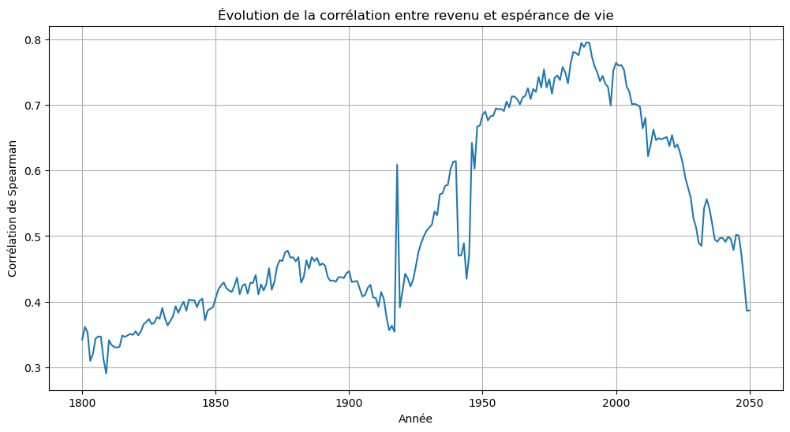

```python
# Charger les données de l'espérance de vie et nettoyer
df_life = pd.read_csv('life_expectancy_years.csv', index_col='country')
for col in df_life.columns:
    df_life[col] = pd.to_numeric(df_life[col], errors='coerce')

# Joindre les deux DataFrames sur le pays et l'année
df_income_transposed = df_income.T.stack().reset_index()
df_income_transposed.columns = ['year', 'country', 'income']

df_life_transposed = df_life.T.stack().reset_index()
df_life_transposed.columns = ['year', 'country', 'life']

df_merged = pd.merge(df_income_transposed, df_life_transposed, on=['year', 'country'])

# Calculer la corrélation de Spearman pour chaque année
# La corrélation de Spearman est robuste aux relations non linéaires
correlation_time = df_merged.groupby('year').apply(lambda x: x['income'].corr(x['life'], method='spearman'))

# Tracer l'évolution de la corrélation
plt.figure(figsize=(12, 6))
correlation_time.plot()
plt.title("Évolution de la corrélation entre revenu et espérance de vie")
plt.xlabel("Année")
plt.ylabel("Corrélation de Spearman")
plt.grid(True)
plt.show()
```

**Point à retenir Description** **Matrice de corrélation** La heatmap sur un sous-ensemble de pays montre des corrélations très fortes entre pays développés, indiquant des trajectoires économiques similaires.

**Histogramme des corrélations** L'histogramme pour tous les pays montre une distribution asymétrique négativement, avec la majorité des paires de pays ayant des corrélations positives et fortes, mais quelques paires ayant une corrélation faible ou négative.

**Pays les moins corrélés** L'analyse révèle des pays dont les revenus sont en moyenne les moins corrélés et des paires de pays avec la plus faible corrélation, mettant en évidence les économies avec des trajectoires divergentes.